# Region based spatial transcriptomics analysis with scider

Mengbo Li, Ning Liu, Quoc Hoang Nguyen and Yunshun Chen

Source: [`vignettes/getting-started.Rmd`](https://github.com/ChenLaboratory/scider/blob/devel/vignettes/getting-started.Rmd)

## Introduction

`scider` is a user-friendly R package providing functions to model the global density of cells in a slide of spatial transcriptomics data. All functions in the package are built on the `SpatialExperiment` object, allowing integration into various spatial transcriptomics-related packages from Bioconductor. After modelling density, `scider` supports several downstream analyses, including colocalization analysis, boundary detection and differential density analysis.

The plotting functions return `ggplot` objects, so figures can be further customised with any `ggplot2` layer.

This vignette walks through a typical workflow on a Xenium breast cancer dataset.

## Load Package

```r
library(scider)
library(SpatialExperiment)
library(ggplot2)
```

## Load Example Data

The example dataset is a small `SpatialExperiment` object (one Xenium breast cancer section) hosted as a GitHub Release asset. Download it once and cache locally:

```r
data_url   <- "https://github.com/ChenLaboratory/example_data/releases/download/v1.0.0/spe_xenium_bc_s1rep1.rds"
cache_dir  <- tools::R_user_dir("scider", "cache")
data_file  <- file.path(cache_dir, "spe_xenium_bc_s1rep1.rds")

if (!file.exists(data_file)) {
  dir.create(cache_dir, recursive = TRUE, showWarnings = FALSE)
  download.file(data_url, data_file, mode = "wb")
}

spe <- readRDS(data_file)
spe
```

```
#> class: SpatialExperiment
#> dim: 313 163797
#> metadata(0):
#> assays(1): counts
#> rownames(313): ABCC11 ACTA2 ... ZEB2 ZNF562
#> rowData names(3): ID Symbol Type
#> colnames(163797): cell_1 cell_2 ... cell_167779 cell_167780
#> colData names(12): cell_id transcript_counts ... gene_counts cell_type
#> reducedDimNames(0):
#> mainExpName: NULL
#> altExpNames(0):
#> spatialCoords names(2) : x_centroid y_centroid
#> imgData names(1): sample_id
```

## Data exploration

The Xenium data was annotated by 10X Genomics. The cell type annotation is summarized below.

```r
table(colData(spe)$cell_type)
```

```
#>
#>           Stromal    Invasive_Tumor              DCIS       Macrophages            Myoepi       Endothelial      CD4+_T_Cells      CD8+_T_Cells            Others           B_Cells
#>             41422             38149             24604             12798              9938              8931              8453              6940              5769              4987
#> Perivascular-Like               DCs        Mast_Cells
#>               847               792               167
```

We can visualize the spatial distribution of all the cell types across the tissue as follows.

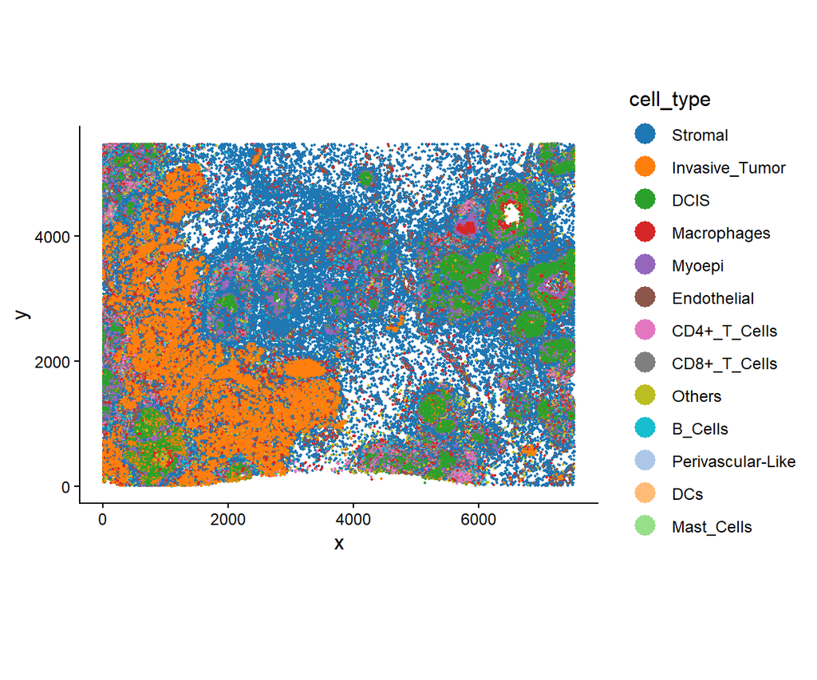

```r
plotSpatial(spe, group.by = "cell_type")
```

Or visualize the spatial distribution of specific cell types (e.g., DCIS and Invasive Tumor).

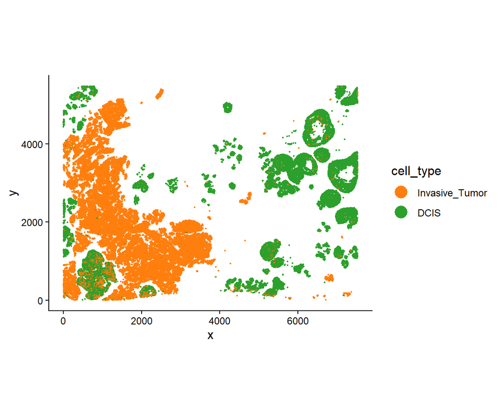

```r
COI <- c("DCIS", "Invasive_Tumor")
sel <- spe$cell_type %in% COI
plotSpatial(spe[, sel], group.by = "cell_type")
```

We can also examine the expression level of each individual gene spatially. Because the returned object is a `ggplot`, we can add a title with `ggtitle()`.

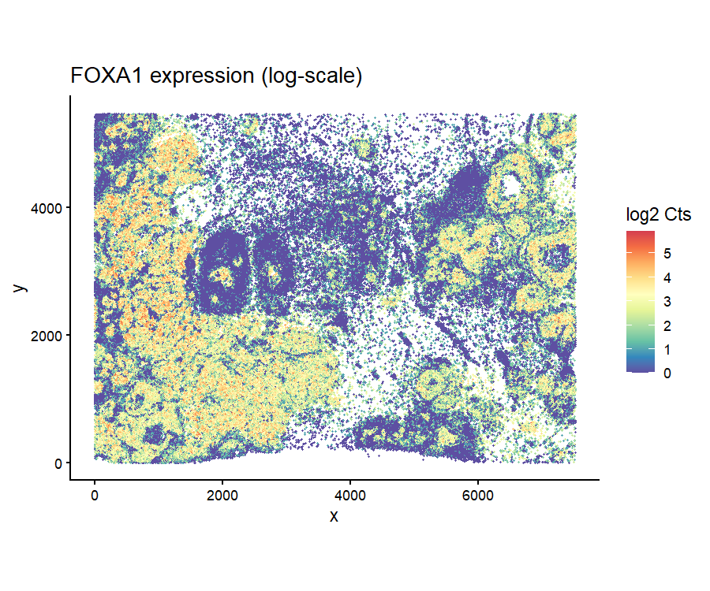

```r
plotSpatial(spe, feature = "FOXA1", type = "log") +
  ggtitle("FOXA1 expression (log-scale)")
```

## Cell type density

`scider` implements grid-based density analysis for spatial transcriptomics data. We first calculate density for each cell type using function `gridDensity`. The calculated density and grid information are saved in the `metadata` of the `SpatialExperiment` object. The size of the grid (bin) is set by the `grid.length.x` parameter, and the level of smoothing is set by `bandwidth`.

```r
spe <- gridDensity(spe, grid.length.x = 50, bandwidth = 50)
```

We can visualise the overall (all cell types) density of the whole tissue using function `plotDensity`. The `probs` parameter indicates the density percentile below which the grids are filtered (not plotted). Setting `probs` to 0 will plot everything including the background.

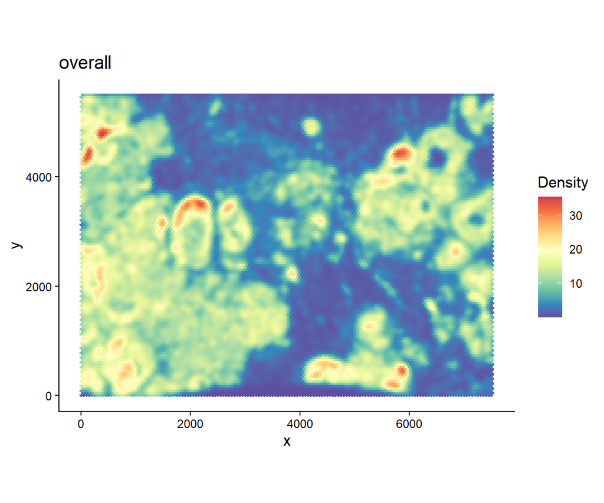

```r
plotDensity(spe, probs = 0)
```

Alternatively, user can specify `cutoff` to filter grids with low cell density. The density values represent the expected numbers of cells at each grid.

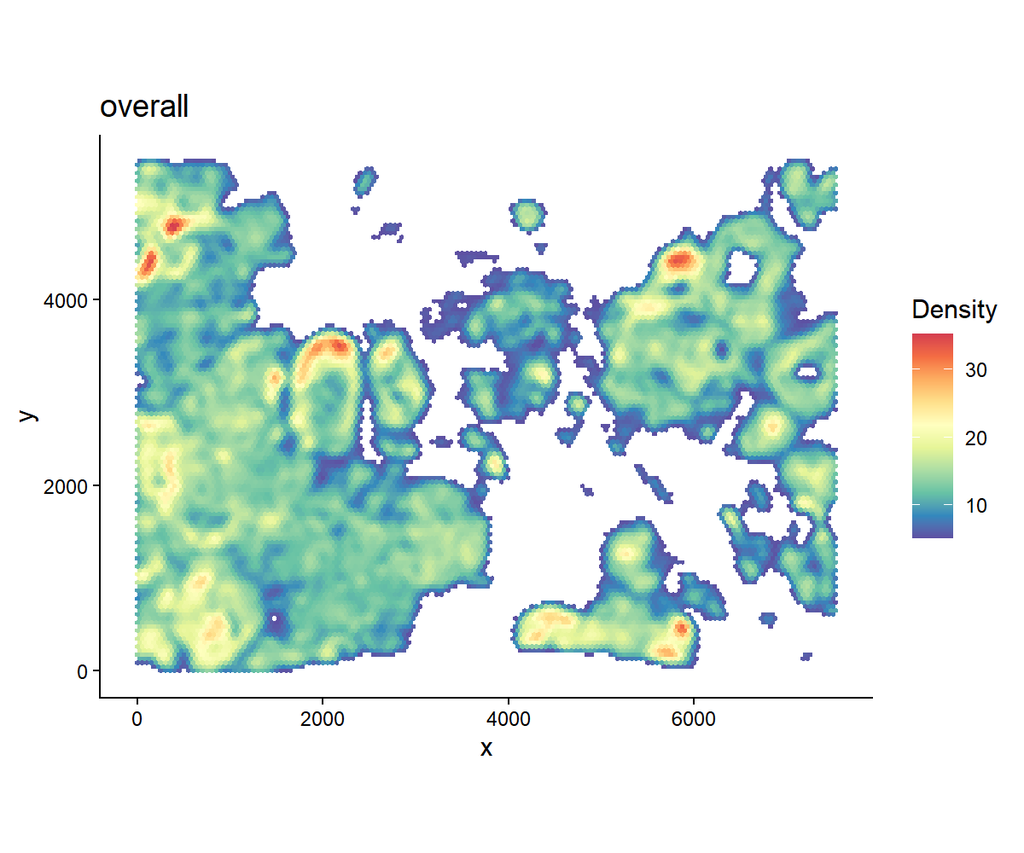

```r
plotDensity(spe, cutoff = 5)
```

We can also visualise the density of specific cell type(s).

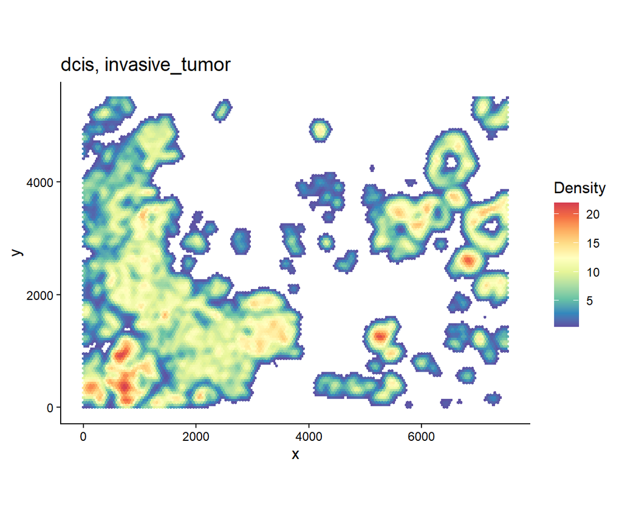

```r
plotDensity(spe, coi = COI)
```

## Find Regions-of-interest (ROIs)

After obtaining grid-based density for each cell type, we can then detect regions-of-interest (ROIs) based on density of certain cell type(s). This is done by using the `findROI` function.

Here we identify ROIs based on the cell density of DCIS and invasive tumor. The `min.density` parameter filters grids with low cell density, whereas the `ngrid.min` gives the minimum number of grids that each ROI should have.

```r
spe <- findROI(spe, coi = COI, min.density = 0.5, ngrid.min = 20)
```

```
#> Overwriting the probs argument. Grids are filtered by the min.density value.
```

The ROIs can then be visualized using `plotROI`.

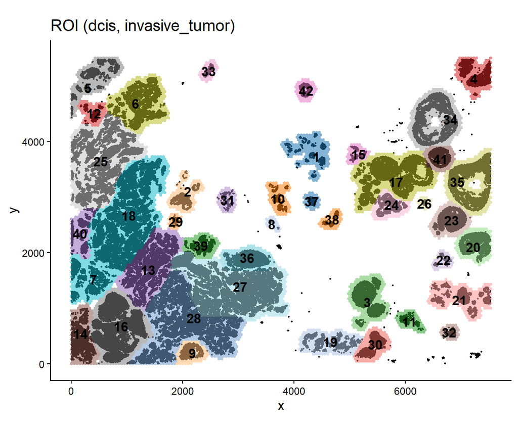

```r
plotROI(spe, roi = COI)
```

## Testing relationship between cell types

After defining ROIs, we can test whether the densities of any two cell types are spatially correlated, within each ROI or overall while accounting for ROI variation. This is done with function `corDensity`. By default it compares the observed correlation between two cell type densities with the correlations obtained under random labelling: cell locations are kept, cell type labels are shuffled and the densities are recomputed (999 times by default). Because the p-values come from these random relabellings, we set a seed for reproducible results. The modified t-test of Dutilleul, which accounts for the spatial autocorrelation between neighbouring grids, is available with `method = "modified.ttest"`.

```r
set.seed(1)
results <- corDensity(spe, roi = COI)
```

We can examine the correlation between each pair of cell types in each ROI. Besides the observed correlation (`cor.coef`), the results give its expected value under random labelling (`cor.expected`), the difference between the two (`shift`), and one-sided p-values for positive (`p.Pos`) and negative (`p.Neg`) association.

```r
results$ROI
```

```
#> DataFrame with 3276 rows and 9 columns
#>        celltype1      celltype2         ROI     ngrid   cor.coef cor.expected      shift     p.Pos     p.Neg
#>      <character>    <character> <character> <integer>  <numeric>    <numeric>  <numeric> <numeric> <numeric>
#> 1        Stromal Invasive tumor           1       202 -0.0774348     0.613646  -0.691081         1     0.001
#> 2        Stromal Invasive tumor           2       128 -0.6751916     0.732848  -1.408039         1     0.001
#> 3        Stromal Invasive tumor           3       248 -0.8019436     0.825980  -1.627924         1     0.001
#> 4        Stromal Invasive tumor           4       171 -0.8022129     0.778160  -1.580373         1     0.001
#> 5        Stromal Invasive tumor           5       227 -0.6857148     0.769038  -1.454753         1     0.001
#> ...          ...            ...         ...       ...        ...          ...        ...       ...       ...
#> 3272        D cs     Mast cells          38        54         NA  0.055113517         NA        NA        NA
#> 3273        D cs     Mast cells          39       108 -0.0571595  0.015804798 -0.0729643 0.5844422  0.416581
#> 3274        D cs     Mast cells          40       132  0.1020318  0.010188023  0.0918438 0.3750000  0.626000
#> 3275        D cs     Mast cells          41       103  0.6772782 -0.000472391  0.6777506 0.0111675  0.989848
#> 3276        D cs     Mast cells          42        62         NA  0.093383468         NA        NA        NA
```

Or the correlation between each pair of cell types across all ROIs. The overall results also count the ROIs in which the observed correlation lies above (`n.above`) or below (`n.below`) its expected value, or is significantly so (`n.sig.Pos`, `n.sig.Neg`):

```r
results$overall
```

```
#> DataFrame with 78 rows and 12 columns
#>             celltype1      celltype2   cor.coef cor.expected      shift     p.Pos     p.Neg     n.roi   n.above   n.below n.sig.Pos n.sig.Neg
#>           <character>    <character>  <numeric>    <numeric>  <numeric> <numeric> <numeric> <integer> <integer> <integer> <integer> <integer>
#> 1             Stromal Invasive tumor -0.5021193     0.678683 -1.1808023     1.000     0.001        41         0        41         0        41
#> 2             Stromal           Dcis -0.2910660     0.632843 -0.9239088     1.000     0.001        40         1        39         0        39
#> 3             Stromal    Macrophages  0.2575724     0.550896 -0.2933232     1.000     0.001        42         8        34         3        20
#> 4             Stromal         Myoepi  0.0541824     0.514875 -0.4606926     1.000     0.001        40         1        39         0        33
#> 5             Stromal    Endothelial  0.5209102     0.499207  0.0217035     0.132     0.869        42        17        25         8         8
#> ...               ...            ...        ...          ...        ...       ...       ...       ...       ...       ...       ...       ...
#> 74            B cells           D cs   0.318719    0.1409202  0.1777986     0.001     1.000        40        31         9        13         2
#> 75            B cells     Mast cells   0.261348    0.0776230  0.1837254     0.001     1.000        39        26        13         7         1
#> 76  Perivascular like           D cs   0.175935    0.0770501  0.0988851     0.001     1.000        40        26        14         7         0
#> 77  Perivascular like     Mast cells   0.132619    0.0473268  0.0852918     0.014     0.987        39        24        15         5         1
#> 78               D cs     Mast cells   0.164990    0.0449535  0.1200369     0.001     1.000        38        22        16         7         3
```

We can visualise the statistics between each pair of cell types using function `plotCorHeatmap`. Two cell type densities tend to rise and fall together with the local number of cells, so the observed correlations are mostly positive. The `shift` measures co-localization (positive) or segregation (negative) beyond this, and is easier to interpret. Here we show the shift in each ROI for a selection of cell types:

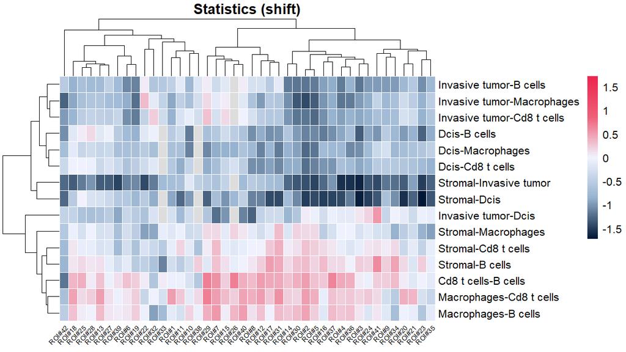

```r
plotCorHeatmap(results, level = "ROI", stats = "shift",
               cell.type = c("DCIS", "Invasive_Tumor", "Stromal",
                             "Macrophages", "CD8+_T_Cells", "B_Cells"),
               fontsize_col = 6)
```

Or the shift for all cell type pairs across the whole slide:

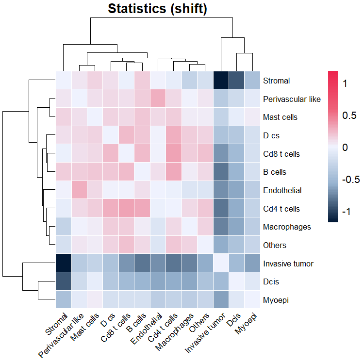

```r
plotCorHeatmap(results, stats = "shift", fontsize_row = 8, fontsize_col = 8)
```

### Accounting for tissue compartments

The strongest results above are between tumour cells and the surrounding cells, which largely reflects the separation of the tumour from the rest of the tissue. To look for structure beyond such compartments, `corDensity` can shuffle the cell type labels only among cells of the same compartment, given by a column of `colData` passed to `permute.within`. The arrangement explained by the compartments then becomes part of the expected value.

Here we group the cell types into epithelial, stromal and immune compartments. Cells annotated as `Others` are placed in the stromal compartment. Compartments should be coarse: a cell type that is the only type in its compartment is never shuffled.

```r
compartment <- c(DCIS = "epithelial", Invasive_Tumor = "epithelial",
                 Myoepi = "epithelial",
                 Stromal = "stromal", Endothelial = "stromal",
                 `Perivascular-Like` = "stromal", Others = "stromal",
                 Macrophages = "immune", `CD4+_T_Cells` = "immune",
                 `CD8+_T_Cells` = "immune", B_Cells = "immune",
                 DCs = "immune", Mast_Cells = "immune")
spe$compartment <- unname(compartment[spe$cell_type])
table(spe$compartment)
```

[output not shown]

```r
set.seed(1)
results_within <- corDensity(spe, roi = COI, permute.within = "compartment")
```

For two cell types in the same compartment, a positive shift now means that they share neighbourhoods more than two random cells of that compartment would. For cell types in different compartments, it means that they lie closer to each other than random cells of their compartments would. The pairs with the largest shifts are:

```r
res <- as.data.frame(results_within$overall)
res <- res[order(abs(res$shift), decreasing = TRUE),
           c("celltype1", "celltype2", "cor.coef", "cor.expected", "shift",
             "n.sig.Pos", "n.sig.Neg")]
res[3:5] <- round(res[3:5], 2)
print(head(res, 12), row.names = FALSE)
```

```
#>       celltype1      celltype2 cor.coef cor.expected shift n.sig.Pos n.sig.Neg
#>         Stromal Invasive tumor    -0.50         0.85 -1.35         0        37
#>         Stromal           Dcis    -0.29         0.81 -1.10         0        40
#>         Stromal        B cells     0.57        -0.27  0.85        30         3
#>         Stromal    Endothelial     0.52        -0.20  0.72        29         1
#>         Stromal    Cd8 t cells     0.42        -0.29  0.71        33         2
#>  Invasive tumor           Dcis     0.12         0.81 -0.69         2        32
#>          Myoepi    Endothelial     0.05         0.70 -0.65         0        38
#>     Macrophages         Myoepi     0.08         0.73 -0.65         0        39
#>         Stromal    Cd4 t cells     0.44        -0.20  0.64        28         3
#>          Myoepi    Cd4 t cells     0.09         0.69 -0.60         0        36
#>            Dcis         Myoepi     0.37        -0.19  0.56        35         0
#>         Stromal         Others     0.25        -0.28  0.53        25         1
```

Within the epithelium, DCIS cells co-localize with myoepithelial cells and segregate from invasive tumour cells, consistent with the myoepithelial layer that surrounds ducts in DCIS but is lost in invasive carcinoma. The fibroblast-like stromal cells lie further from tumour cells, and closer to B and T cells, than random cells of the respective compartments would.

## Cell density contour

Another strategy to partition a tissue spatially is to construct cell density contours. This can be done using the `getContour` function.

The `equal.cell` parameter ensures roughly equal cell numbers across all density levels.

```r
spe <- getContour(spe, coi = COI, equal.cell = TRUE)
```

```
#> Finding contour using total density of input COIs.
#> Using bins = 10 to draw contours with equal cell numbers.
```

The constructed contours can be visualised using `plotContour`.

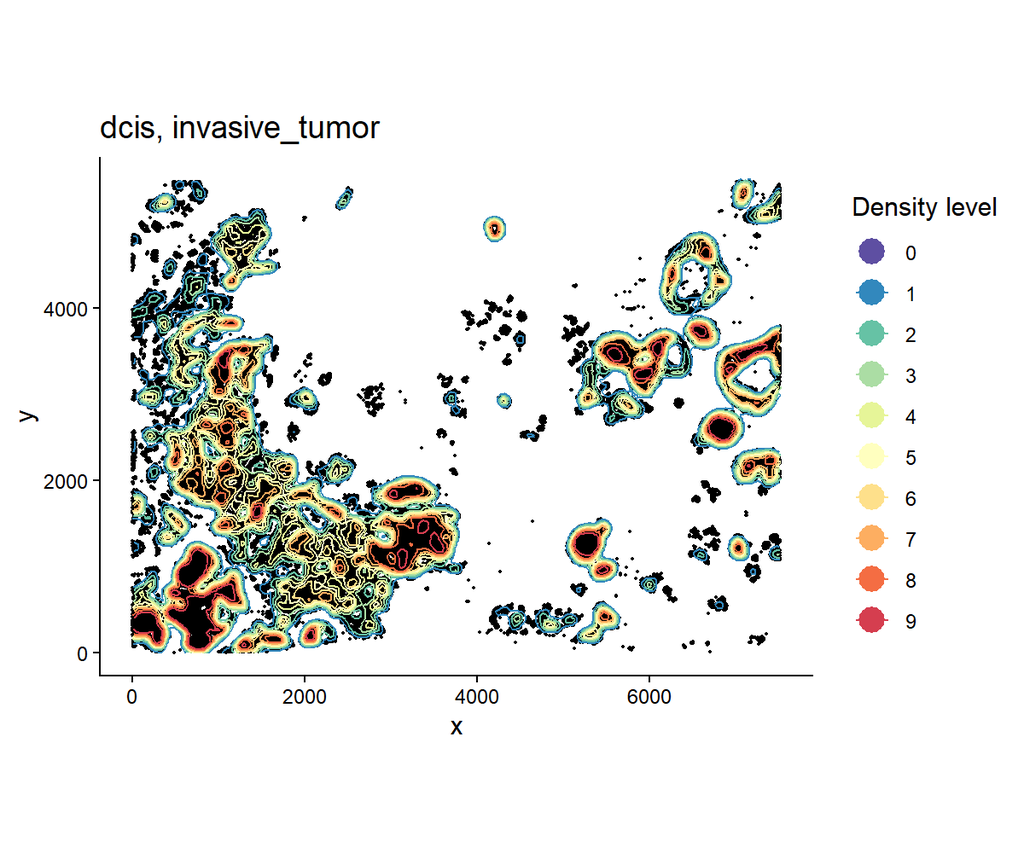

```r
plotContour(spe, coi = COI)
```